# Riverine Changepoints

Mae Hutchison

2025-12-03

# Introduction to the data

The U.S. Geological Survey (USGS) river gage data provides continuous monitoring of streamflow conditions across thousands of sites in the United States. These gages measure the height (stage) of a river or stream, which is then used to estimate the flow rate or discharge—typically reported in cubic feet per second (cfs). Data collection is done using automated instruments such as pressure transducers, radar sensors, or float-operated devices that record water level at regular intervals. Flow measurements are derived from stage-discharge relationships established through field measurements using techniques like current meters or acoustic Doppler devices. The USGS reports this data in near real-time via its National Water Information System (NWIS), making it accessible for flood forecasting, water resource management, and ecological studies.

For this project, I focused on three gages in Kerr County Texas, between June and August 2025.

```r
data<-data.pull() # wrapper for USGS API, defined in utils.R
```

```
## Requesting:
## https://api.waterdata.usgs.gov/ogcapi/v0/collections/daily/items?f=json&lang=en-US&time=2025-06-01T00%3A00%3A00Z%2F2025-08-31T00%3A00%3A00Z&limit=10000
```

```r
site_ids<- unique(data$monitoring_location_id)
pour_points <- data.frame(featureSource = rep("nwissite", length(site_ids)),
                    featureID = site_ids)
upstream_network<-apply(pour_points, 1, navigate_nldi, mode="upstreamMain")
flowlines <- do.call(rbind, lapply(upstream_network, function(x) x$UM_flowlines))

leaflet(data = data) %>%
  addTiles() %>%
  addMarkers(data=data, popup = ~monitoring_location_id) %>%
  addPolylines(data=flowlines, color='blue')%>%
  addCircleMarkers(data=data,
                   radius = 5,
                   color = "blue",
                   stroke = FALSE,
                   fillOpacity = 0.7) %>%
  setView(lng = -99.14, lat = 30.05, zoom = 11)
```

[interactive chart not shown]

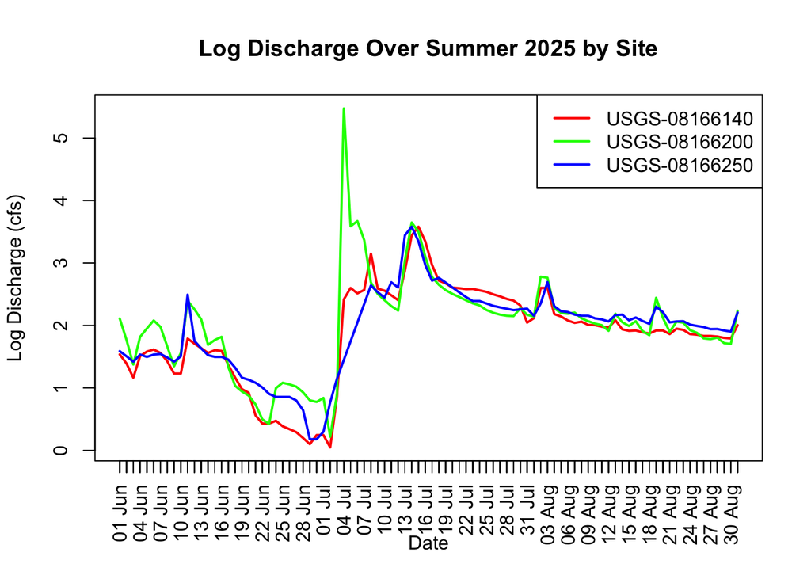

```r
data <- data.resolveNA(data) # defined in utils.R
plot(NULL,
     xlim = range(data$time), xaxt = "n",
     ylim = range(log10(data$discharge_max)),
     xlab = "Date", ylab = "Log Discharge (cfs)",
     main = "Log Discharge Over Summer 2025 by Site")
axis(side = 1, at = data$time, labels = format(data$time, "%d %b"), las = 2)
discharge_sites <- unique(data$monitoring_location_id)
colors <- rainbow(length(discharge_sites))
for (i in seq_along(discharge_sites)) {
  site_data <- subset(data,
                      monitoring_location_id == discharge_sites[i])
  lines(site_data$time, log10(site_data$discharge_max), col = colors[i], lwd = 2)
}
legend("topright", legend = discharge_sites, col = colors, lwd = 2)
```

A more in-depth exploration of this gage data set and flowlines connecting each gage is provided in `data_explore.R`

# Description of the Bayesian Model

The U.S. Geological Survey (USGS) has long employed a structured approach to modeling river gage flow, relying on statistical hydrology and empirical data analysis. Central to its methodology is the use of annual peak flow data, which are collected from thousands of gaging stations across the United States. These data serve as the foundation for flood frequency analysis, water resource planning, and hydrologic modeling. The statistical distribution most commonly used by the USGS for modeling peak flows is the Log-Pearson Type III distribution, as recommended in Bulletin 17B and 17C. This distribution is favored for its ability to accommodate skewness in the data and its suitability for log-transformed flow values. It assumes that annual peak flows are independent and identically distributed, and that their logarithms follow a Pearson Type III distribution—a form of the gamma distribution with skew.

Parameter estimation for the Log-Pearson III model typically involves calculating the mean, standard deviation, and skewness of the log-transformed peak flows, using methods such as the method of moments or maximum likelihood estimation. More recently, Bayesian techniques have been introduced to improve uncertainty quantification and incorporate regional information, especially in Bulletin 17C. This update also includes the Grubbs-Beck test for identifying low outliers and supports generalized skew estimation using regional data. For low-flow statistics, such as the 7Q10 or 30Q5, the USGS often employs empirical frequency analysis and may use distributions like the log-normal or Weibull, though these are less standardized than those used for peak flows. Daily streamflow modeling, on the other hand, is typically handled through hydrologic simulation models such as HEC-HMS or SWAT, or through stochastic time series models like ARIMA.

Traditional USGS modeling assumes stationarity—that the statistical properties of streamflow do not change over time. It also assumes independence between annual peak flows and homogeneity of the data, meaning all observations are drawn from a single population. These assumptions are increasingly challenged by climate change, land use changes, and other nonstationary influences. As a result, newer methods, including Bayesian changepoint detection, are being explored to better capture shifts in hydrologic regimes and improve the robustness of flow modeling. (England et al. 2018)

## Application and Main features

The Log-Pearson Type III distribution is widely used in hydrology to model peak streamflows. It applies a Pearson Type III distribution to the log-transformed discharge data.

Let $Q$ be the annual peak discharge. Define:

$$X = \log_{10}(Q)$$
Then $X$ is assumed to follow a Pearson Type III distribution.

### Probability Density Function (PDF)

The PDF of the Pearson Type III distribution for $X$ is:

$$f(x|\kappa, \theta,\tau) = \frac{(x - \tau)^{\kappa - 1} e^{-(x -
\tau)/\theta}}
{\theta^{\kappa} \Gamma(\kappa)}, \quad x > \tau$$

Where: - $\kappa > 0$ is the shape parameter  
- $\theta > 0$ is the scale parameter  
- $\tau$ is the location parameter  
- $\Gamma(\cdot)$ is the gamma function

The parameters can be estimated using the first three L-moments of past observed data (mean $\mu$, standard deviation $\sigma$, skewness $\gamma$).

- shape $\kappa = (2/\gamma)^2$
- scale $\theta = 2\sigma/\gamma$
- location $\tau = \mu - \theta \cdot \kappa$.

Note that shape and scale are both dependent on skewness $\gamma$. When two parameters in an MCMC sampler are highly correlated, the posterior distribution becomes elongated along a diagonal direction, making it difficult for standard proposal mechanisms to explore efficiently. This leads to slow mixing, high autocorrelation between samples, and poor convergence because the sampler must take very small steps to maintain reasonable acceptance rates. As a result, the effective sample size decreases, requiring many more iterations to achieve accurate estimates. Strong correlations also complicate convergence diagnostics and can cause numerical instability in adaptive algorithms.

### Hydrologic Parameterization

In hydrologic applications, the distribution is often parameterized using: - Mean $\mu$ - Standard deviation $\sigma$ - Skew coefficient $\gamma$

These are computed from the log-transformed data $X = \log_{10}(Q)$, and used to estimate flood quantiles via:

$$X_T = \mu + K_T \cdot \sigma$$

Where: - $X_T$ is the log of the discharge for return period $T$ - $K_T$ is a frequency factor that depends on $T$ and the skew $\gamma$

Then the estimated discharge for return period $T$ is:

$$Q_T = 10^{X_T}$$

## Other methods

In hydrologic modeling, both the log-normal distribution and the generalized extreme value (GEV) distribution are also commonly used to represent different aspects of streamflow behavior, particularly when analyzing discharge data from river gages.

The log-normal distribution is often applied to daily discharge values, especially when modeling typical flow conditions or low flows. This choice is motivated by the fact that streamflow data are strictly positive and often exhibit right-skewed behavior—meaning that most values are relatively low, but occasional high flows occur. By taking the logarithm of discharge values, the data tend to approximate a normal distribution, which simplifies statistical analysis and parameter estimation. The log-normal model is frequently used in water quality modeling, ecological studies, and operational forecasting.

The GEV distribution is specifically designed to model extreme values, such as annual maximum daily discharges or flood peaks. It encompasses three types of extreme value distributions (Gumbel, Frechet, and Weibull) through its shape parameter, allowing flexibility in modeling different tail behaviors. The GEV is grounded in extreme value theory, which states that the distribution of block maxima (e.g., yearly maximum flows) converges to a GEV distribution under broad conditions. This makes it particularly suitable for flood frequency analysis, infrastructure design, and risk assessment, where understanding the probability of rare but high-impact events is critical.

For the purposes of this report, only the Log-Pearson III distribution is used for setting the prior belief.

# Implementation of the model

The prior beleif is set based on the 2024 summer flows of the same gages.

```r
data.prev <- data.pull(datestring="2024-06-01T00:00:00Z/2024-08-31T00:00:00Z")
```

```
## Requesting:
## https://api.waterdata.usgs.gov/ogcapi/v0/collections/daily/items?f=json&lang=en-US&time=2024-06-01T00%3A00%3A00Z%2F2024-08-31T00%3A00%3A00Z&limit=10000
```

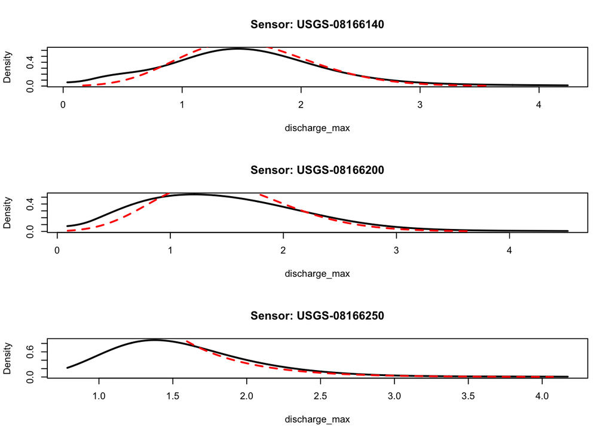

```r
data.prev <- data.resolveNA(data.prev)

# est.params defined in my_functions.R using method of moments
plot.density(data.prev)
```

```r
gage.data.prev <- split(data.prev$discharge_max,
                        data.prev$monitoring_location_id)
params <- purrr::map(lapply(gage.data.prev, est.lp3), 'para')
kable_tables <- lapply(names(params), function(name) {
      df <- params[[name]]
      kable(t(df), caption = name)
    })
kable_tables
```

[[1]]

USGS-08166140

| mu | sigma | gamma |
| --- | --- | --- |
| 1.56703 | 0.5530332 | 0.402204 |

[[2]]

USGS-08166200

| mu | sigma | gamma |
| --- | --- | --- |
| 1.491659 | 0.5781152 | 0.4836439 |

[[3]]

USGS-08166250

| mu | sigma | gamma |
| --- | --- | --- |
| 1.584861 | 0.4220775 | 1.990732 |

This report compares three different implementations of Bayesian Online Changepoint Detection (BOCPD). First, an analytical implementation using gamma-gamma conjugate priors, then an MCMC sampling method. Finally a brief demonstration is shown of the `Rbeast` package using an ensemble algorithm method.

## Analytical implementation using conjugate priors

The full implementation of this method is provided in `bocpd_gamma.cpp` and is imported into R using the `Rcpp` package. This method is implemented based on the procedure explained in Adams and MacKay (2007).

```r
sourceCpp(file='analytical_bocpd/bocpd_gamma.cpp')
```

For this solution, we use a simplified model where $X \sim \text{Gamma}(\alpha,\beta)$ with shape parameter $\alpha$ and rate parameter $\beta$ (inverse of scale).

With a Gamma-Gamma conjugage prior, the likelihood is Gamma and the conjugate prior for the rate parameter $\beta$ (given $\alpha$) is also Gamma.

- Prior: $\beta \sim \text{Gamma}(a_0, b_0)$
- Likelihood: $x_i | \beta \sim \text{Gamma}(\alpha, \beta)$
- Analytical posterior (with $n$ observed data points): $\beta | x_{1:n}\sim \text{Gamma}(a_0+n\alpha, b_0+\sum_{i=1}^n x_i)$

With online updates, we can only see past data at each timestep. When a new observation $x_t$ arrives:

- update sufficient statistics
  - $n \gets n+1$
  - $S \gets S+x_t$
- Posterior becomes $\beta|x_{1:n} \sim \text{Gamma}(a_0+n\alpha, b_0 +S)$

Where $S$ is the running sum $\sum_{i=1}^n x_i$.

Using Adams and MacKay (2007) BOCPD framework,

- Maintain a run-length distribution $\Pr(r_t|x_{1:t})$ where $r_t = \text{number of observations since last changepoint}$
- For each possible run length, compute predictive probability $\Pr (x_t | r_t) = \int \Pr(x_t|\beta) \Pr(\beta | \text{data in run}) \delta \beta$.

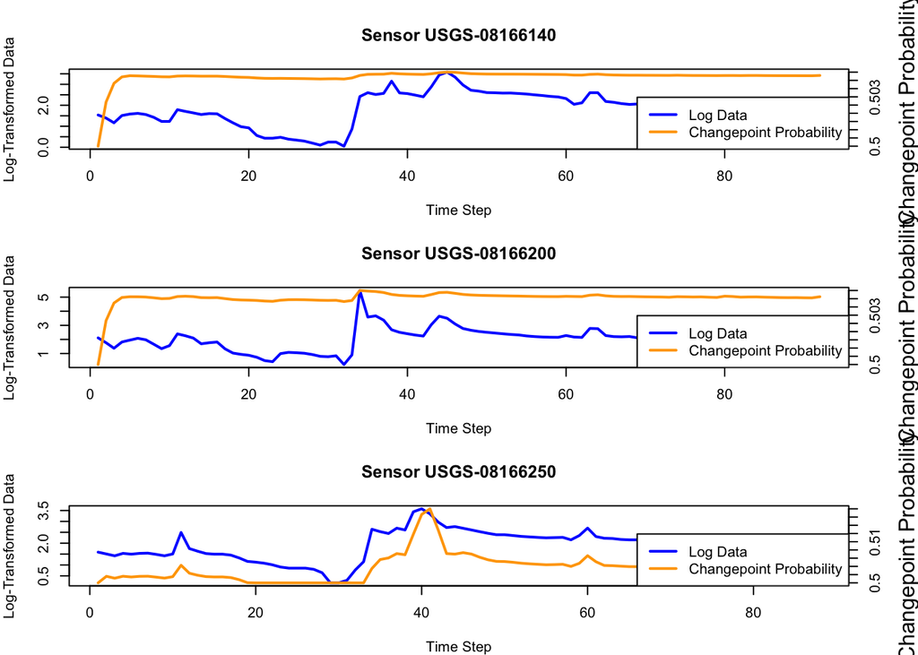

```r
gage.data <- split(data$discharge_max, data$monitoring_location_id)

results <-  list()
for(gage in names(gage.data)){
  # gage values to assess in "real-time"
  gage_values <- gage.data[[gage]]

  # prior belief only based on past observed values
  prior <- est.lp3(gage.data.prev[[gage]])[['para']]

  # translate L-moments into log Pearson III parameters
  scale <- 2*prior[['sigma']]/prior[['gamma']]
  shape <- 4/prior[['gamma']]^2
  location <- prior[['mu']] - scale*shape

  results[[gage]] <- bocpd_pearsonIII(data = log10(gage_values)
                    , prior_shape = shape
                    , prior_scale = scale
                    , location = location
                    , hazard_lambda = 2
                    , adaptive_hazard = TRUE)

}

# plot results
plot.changepoints(gage.data, results)
```

Using analytical solutions with conjugate priors for Bayesian online changepoint detection offers significant benefits: it enables exact posterior updates in closed form, eliminating the need for iterative sampling and reducing computational overhead. This makes real-time processing fast and efficient, with low latency and high numerical stability. Additionally, the approach simplifies implementation by avoiding convergence diagnostics and parameter tuning, while scaling well to large datasets since updates depend only on the previous state and the new observation.

## MCMC implementation

The MCMC implementation uses `rstan` to define the model and then runs MCMC sampling for each time step, using only previous time steps data.

```r
data {
  int<lower=1> N;
  array[N] real<lower=0> y;
  real<lower=0> shape_prior;
  real<lower=0> scale_prior;
  real location_prior;
}

parameters {
  real<lower=0> shape;
  real<lower=0> scale;
  real location;
}
model {
  // Priors
  shape ~ lognormal(shape_prior, 2);
  scale ~ lognormal(scale_prior, 2);
  location ~ normal(location_prior, 2);

  // Likelihood
  for (n in 1:N) {
    target += logpearson3_lpdf(y[n] | shape, scale, location);
  }
}
```

For each time step:
- sample for each run length before current timestep
- calculate the predictive probability of the observed posterior.
- calculate the run length probability
- calculate changepoint probability
$$P(r_t = 0 \mid x_{1:t}) \propto \sum_{r_{t-1}} P(r_t = 0 \mid r_{t-1})
\cdot P(x_t \mid r_{t-1}, x_{1:t-1}) \cdot P(r_{t-1}, x_{1:t-1})$$

This method can become computationally expensive very quickly due to the recursive nature of the changepoint probability requiring the calculation of the changepoint probability of all possible run legths before the current time step.

An abreviated version of this algorithim is shown in `numerical_bocpd/mcmc_moving_window.R` that samples the posterior at each timestep and calculates the change in individual parameters.

[figure not shown]

Paramater Changepoints

Areas of the sequence where parameters change in quick succession can also slow sampling convergence as each timestep is heavily influenced by the prior parameters of the previous iteration.

## Ensemble Algorithim (Rbeast implementation)

Rbeast is an R package that uses Bayesian Estimator of Abrupt change, Seasonal change, and Trend (BEAST)

Combines:  
- Bayesian changepoint detection for time series.  
- Ensemble modeling to improve robustness and uncertainty quantification.

Each model in the ensemble estimates number and location of changepoints, and segment-specific parameters (mean, trend, seasonality).

Models differ by: Prior settings (e.g., hazard rate, variance), sampling seeds, and different likelihood structures.

The posterior can be computed analytically or computed via MCMC depending on likelihood structure.

Ensemble Aggregation combines posterior samples from all models.

Compute:  
- Posterior inclusion probability for each time point being a changepoint.  
- Credible intervals for trends and seasonal components.

This reduces sensitivity to prior choices and improves stability.

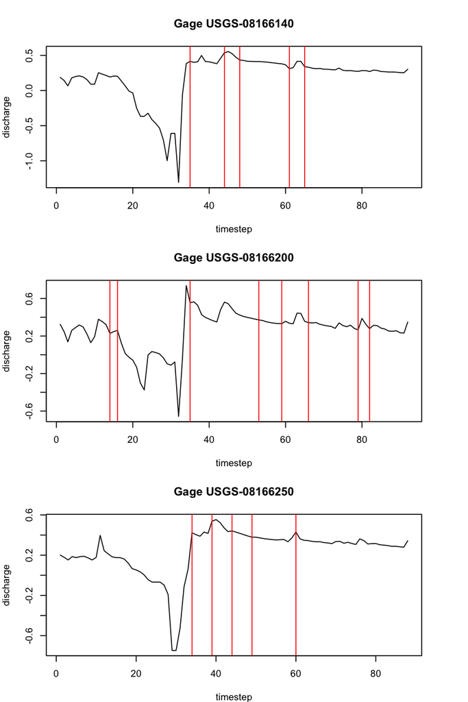

Rbeast detected changepoints

# Comparisons of the implementations

## Comparisons of results

Both analytical and MCMC implementations successfully identified changepoints in the log-transformed discharge data across the three gage sites; however, they differ in sensitivity, resolution, and computational efficiency.

### MCMC Implementation:

A re-paramiterization of the log-Pearson III distribution in which the parameters are less correlated with each other, may produce better sampling results. Additionally, controlling how much the prior belief changes between timesteps could potentially help stabilize the sampling procedure.

## Commentary on implementation choices

The analytical method includes an adaptive hazard function, which improves changepoint detection in nonstationary environments. The MCMC method uses a fixed hazard rate, which may limit responsiveness to abrupt changes.

Overall, the analytical implementation is preferable for operational efficiency and responsiveness, while the MCMC approach is better suited for exploratory analysis and uncertainty-aware modeling.

### Temporal Efficieny

One notable limitation of the MCMC implementation is its lack of temporal efficiency. Despite operating on time-series data, the model does not leverage the sequential structure of the streamflow observations. Instead, it re-samples the entire posterior space from scratch at each time step, using only the data from the current segment. This approach ignores the fact that posterior distributions from previous time steps could serve as informative priors for the next.

This design choice leads to several consequences.Re-running MCMC sampling for every possible segment at each time step is computationally expensive, even with parallelization. The model does not cache or reuse posterior samples, resulting in redundant computation. By treating each segment independently, the implementation misses an opportunity to model temporal dependencies or smooth transitions in parameter estimates. This can lead to inconsistent posterior behavior across adjacent time steps.

There are also scalability concerns. As the number of time steps increases, the number of segments grows quadratically, making the approach increasingly impractical for long time series or real-time applications.

A more efficient alternative would be to implement a sequential Bayesian updating scheme, where posterior distributions from previous time steps are propagated forward. This would preserve the time-series structure, reduce computational load, and improve the coherence of changepoint probability estimates..

# References

Adams, Ryan Prescott, and David J. C. MacKay. 2007. “Bayesian Online Changepoint Detection.” *arXiv Preprint arXiv:0710.3742*. https://arxiv.org/abs/0710.3742.

DeCicco, Laura, David Lorenz, Jordan Read, and Mike Johnson. 2023. *dataRetrieval: R Packages for Discovering and Retrieving Water Data Available from u.s. Federal Hydrologic Web Services*. U.S. Geological Survey. https://cran.r-project.org/package=dataRetrieval.

England, John F. Jr., Timothy A. Cohn, Bruce A. Faber, Jery R. Stedinger, W. O. Jr. Thomas, Andrea G. Veilleux, Julie E. Kiang, and Robert R. Jr. Mason. 2018. “Guidelines for Determining Flood Flow Frequency—Bulletin 17C.” Techniques and Methods Book 4, Chapter B5. U.S. Geological Survey. https://doi.org/10.3133/tm4B5.

Johnson, Mike, Laura DeCicco, and David Lorenz. 2023. *nhdplusTools: Tools for Working with the NHDPlus*. U.S. Geological Survey. https://cran.r-project.org/package=nhdplusTools.

Vogel, Richard M., and Natalie M. Fennessey. 1993. “L-Moment Diagrams Should Replace Product Moment Diagrams.” *Water Resources Research* 29 (6): 1745–52. https://doi.org/10.1029/93WR00341.

Zhao, Kaiguang, Michael A. Wulder, Tongxi Hu, Ryan Bright, Qiusheng Wu, Haiming Qin, Yang Li, et al. 2019. “Detecting Change-Point, Trend, and Seasonality in Satellite Time Series Data to Track Abrupt Changes and Nonlinear Dynamics: A Bayesian Ensemble Algorithm.” *Remote Sensing of Environment* 232: 111181. https://doi.org/https://doi.org/10.1016/j.rse.2019.04.034.